# Torgersons-Metric-MDS-Algorithm

Chloe Jung

January 30, 2021

# TORGERSON’S METRIC MDS ALGORITHM

## PART A – Transform the similarity data to obtain “pseudodistances”.

The following matrix show the confusion probabilities among pairs of five Morse code signals (for E,H,N,S,W) obtained by Rothkopf (1957).

```
E   H   N   S   W
```

```r
# Create the confusion probabilities matrix

A = matrix(
  c(97,9,8,11,9,4,87,16,59,15,4,8,93,17,26,7,37,12,96,12,2,9,12,12,86),
  nrow=5,
  ncol=5
)
rownames(A) <- c("E","H","N","S","W")
colnames(A) <- c("E","H","N","S","W")
A
```

```
##    E  H  N  S  W
## E 97  4  4  7  2
## H  9 87  8 37  9
## N  8 16 93 12 12
## S 11 59 17 96 12
## W  9 15 26 12 86
```

Starting with these probabilities, transform the confusions into dissimilarities that satisfy the axioms of a metric space (=“pseudodistances”). This process involves the following steps 1-4:

### 1. symmetrize the matrix (by averaging the corresponding entries in the upper & lower halves of the matrix), and write it out as a lowerhalf matrix.

```r
# Average the upper and lower halves and put it in the lowerhalf matrix
A1lo <- A[lower.tri(A)]
A1up <- t(A)[lower.tri(t(A))]
A1sym <- A
A1sym[lower.tri(A1sym)] <- (A1up+A1lo)/2


symm <- function(sm) {
sm[upper.tri(sm)]<-t(sm)[upper.tri(sm)]
return(sm)}
symm(A1sym)
```

```
##      E    H    N    S    W
## E 97.0  6.5  6.0  9.0  5.5
## H  6.5 87.0 12.0 48.0 12.0
## N  6.0 12.0 93.0 14.5 19.0
## S  9.0 48.0 14.5 96.0 12.0
## W  5.5 12.0 19.0 12.0 86.0
```

```r
A1sym <- symm(A1sym)
A1sym
```

```
##      E    H    N    S    W
## E 97.0  6.5  6.0  9.0  5.5
## H  6.5 87.0 12.0 48.0 12.0
## N  6.0 12.0 93.0 14.5 19.0
## S  9.0 48.0 14.5 96.0 12.0
## W  5.5 12.0 19.0 12.0 86.0
```

### 2. transform the similarities into dissimilarities (by subtracting each entry from the largest similarity).

```r
# The largest similariy in A1 = 48
# A2 = Dissimilarity Matrix

B = matrix(48,5,5)
A2 <- B - A1sym
A2
```

```
##       E     H     N     S     W
## E -49.0  41.5  42.0  39.0  42.5
## H  41.5 -39.0  36.0   0.0  36.0
## N  42.0  36.0 -45.0  33.5  29.0
## S  39.0   0.0  33.5 -48.0  36.0
## W  42.5  36.0  29.0  36.0 -38.0
```

### 3. for every triple of objects, check if the triangle inequality is satisfied (theoretically, it must be satisfied for all possible permutations of the three points: d(x,y)+d(y,z)  d(x,z), d(x,z) + d(z,y)  d(x,y), d(y,x)+d(x,z)d(y,z), but a little thought can save you a lot of checking here). If the TI is not satisfied, then find the largest violation, C = d(x,z) - (d(x,y)+d(y,z)), and add this constant C to each of the dissimilarities. Verify that the TI is now EXACTLY satisfied for the triple that gave you the largest violation.

```r
# m = size of matrix (# of stimuli).
m<-5; mina<-0  # note you can put two R statements on one line - separate them with semicolon
for (k in 3:m)
{ for (j in 2:(k-1))
  { for (i in 1:(j-1))
      { i;j;k
        a1<-A2[i,j]+A2[j,k]-A2[i,k]
        a2<-A2[j,k]+A2[i,k]-A2[i,j]
        a3<-A2[i,j]+A2[i,k]-A2[j,k]
        a <- min(a1,a2,a3)
        if (a<0) mina<-min(a,mina) }}}
# if minc<0, then the TI is violated, by abs(c)
A3<-matrix(numeric(25),5,5)  # creates a matrix of size 4 x 4 (with entries = 0)
A3<-A3+abs(mina)   # (matrix + scalar) adds the scalar quantity elementwise to the matrix
A3
```

```
##      [,1] [,2] [,3] [,4] [,5]
## [1,]  2.5  2.5  2.5  2.5  2.5
## [2,]  2.5  2.5  2.5  2.5  2.5
## [3,]  2.5  2.5  2.5  2.5  2.5
## [4,]  2.5  2.5  2.5  2.5  2.5
## [5,]  2.5  2.5  2.5  2.5  2.5
```

### 4. write out the resulting matrix as a full matrix (putting 0’s in the diagonal). These numbers nowsatisfy the metric axioms; i.e., they are “pseudodistances”.

```r
A4<-A3+A2
for (i in 1:m) A4[i,i]=0   # put 0s on diagonal of matrix "A4"
# A4 now contains "pseudo-distances", i.e. proximities transformed to satisfy the metric axioms
A4
```

```
##      E    H    N    S    W
## E  0.0 44.0 44.5 41.5 45.0
## H 44.0  0.0 38.5  2.5 38.5
## N 44.5 38.5  0.0 36.0 31.5
## S 41.5  2.5 36.0  0.0 38.5
## W 45.0 38.5 31.5 38.5  0.0
```

## PART B. transform the “pseudodistances” into “pseudo scalar products” (as follows)

### 5. square each entry in this matrix to get dij2.

```r
A4Sq<-A4^2
A4Sq
```

```
##         E       H       N       S       W
## E    0.00 1936.00 1980.25 1722.25 2025.00
## H 1936.00    0.00 1482.25    6.25 1482.25
## N 1980.25 1482.25    0.00 1296.00  992.25
## S 1722.25    6.25 1296.00    0.00 1482.25
## W 2025.00 1482.25  992.25 1482.25    0.00
```

### 6. “double-center” this symmetric matrix using the formula: (include the diagonal entries). The resulting matrix may be thought of as “pseudo scalar products”.

```r
# now compute the row / col means and the grand mean
aveDsq<-c(1:5)
for (i in 1:m) aveDsq[i]<-mean(A4Sq[i,])
aveDsq
```

```
## [1] 1532.70  981.35 1150.15  901.35 1196.35
```

```r
grmean<-mean(aveDsq[])
grmean
```

```
## [1] 1152.38
```

```r
# now we can define matrix A6, the quasi-scalar products matrix
A6<-matrix(numeric(25),5,5)
for (i in 1:m)
{ for (j in 1:m)
  { A6[i,j] <- -0.5*(A4Sq[i,j]-aveDsq[i]-aveDsq[j]+grmean)
   }}
A6
```

```
##          [,1]     [,2]     [,3]     [,4]     [,5]
## [1,]  956.510 -287.165 -224.890 -220.290 -224.165
## [2,] -287.165  405.160 -251.565  362.035 -228.465
## [3,] -224.890 -251.565  573.960 -198.440  100.935
## [4,] -220.290  362.035 -198.440  325.160 -268.465
## [5,] -224.165 -228.465  100.935 -268.465  620.160
```

## PART C. Factor the pseudo-scalar products using PCA.

### 7. Run a principal components analysis (PCA) of this matrix, treating it as covariances, and requesting no rotation of the factor solution. Do a “scree plot” of the size of each eigenvalue for thefive components. How many dimensions appear to approximately characterize the data?

```r
Acomp<-eigen(A6)
Acomp
```

```
## eigen() decomposition
## $values
## [1]  1.227466e+03  1.158874e+03  4.991536e+02  1.818989e-12 -4.544095e+00
##
## $vectors
##            [,1]       [,2]         [,3]       [,4]        [,5]
## [1,] -0.6741496  0.5865000  0.007564536 -0.4472136 -0.03850789
## [2,]  0.5306785  0.2232794  0.087270933 -0.4472136 -0.67890385
## [3,] -0.1398122 -0.4970385 -0.726828529 -0.4472136 -0.07159301
## [4,]  0.4611964  0.2374654 -0.047554867 -0.4472136  0.72708086
## [5,] -0.1779132 -0.5502063  0.679547928 -0.4472136  0.06192390
```

```r
#define principal components (use first two only)
wts<-matrix(numeric(4),2,2)
for (i in 1:2) wts[i,i]<-sqrt(Acomp$values[i])
wts
```

```
##          [,1]     [,2]
## [1,] 35.03521  0.00000
## [2,]  0.00000 34.04224
```

```r
evec<-Acomp$vectors[,1:2]
evec
```

```
##            [,1]       [,2]
## [1,] -0.6741496  0.5865000
## [2,]  0.5306785  0.2232794
## [3,] -0.1398122 -0.4970385
## [4,]  0.4611964  0.2374654
## [5,] -0.1779132 -0.5502063
```

```r
P<-evec%*%wts
P
```

```
##            [,1]       [,2]
## [1,] -23.618974  19.965777
## [2,]  18.592434   7.600931
## [3,]  -4.898350 -16.920306
## [4,]  16.158115   8.083855
## [5,]  -6.233226 -18.730256
```

### 8. Plot the five points in a 2-dimensional space using the “component loadings” for the first two dimensions (label each point appropriately). In a sentence or two, compare your configuration to that obtained by Shepard (and reported in Kruskal & Wish).

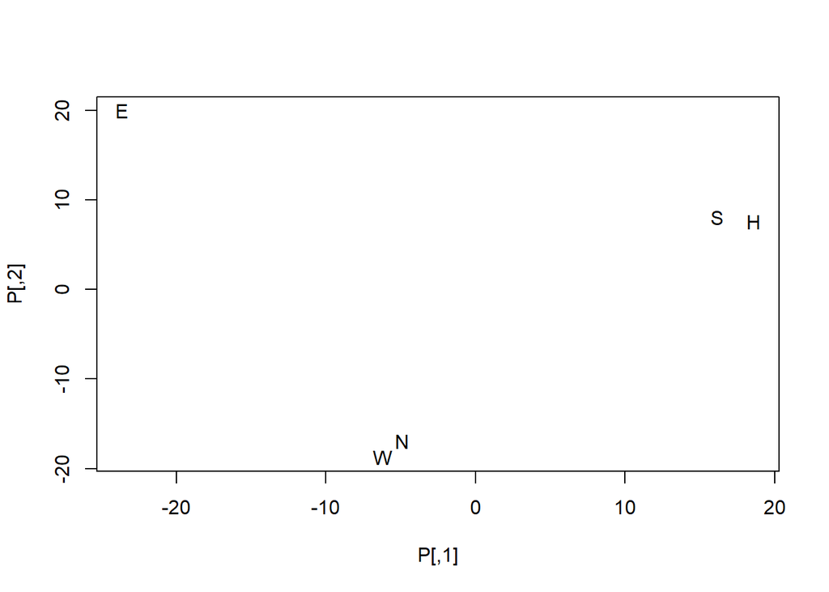

```r
# plot the final 2-dim configuration
plot(P,pch="")
points<-c("E","H","N","S","W")  # prepare to label points
text(P,points)
```

```r
A6comp <- princomp( A6, cor=F, scores=T)
print(A6comp)
```

```
## Call:
## princomp(x = A6, cor = F, scores = T)
##
## Standard deviations:
##       Comp.1       Comp.2       Comp.3       Comp.4       Comp.5
## 5.489396e+02 5.182644e+02 2.232283e+02 2.032181e+00 5.317015e-06
##
##  5  variables and  5 observations.
```

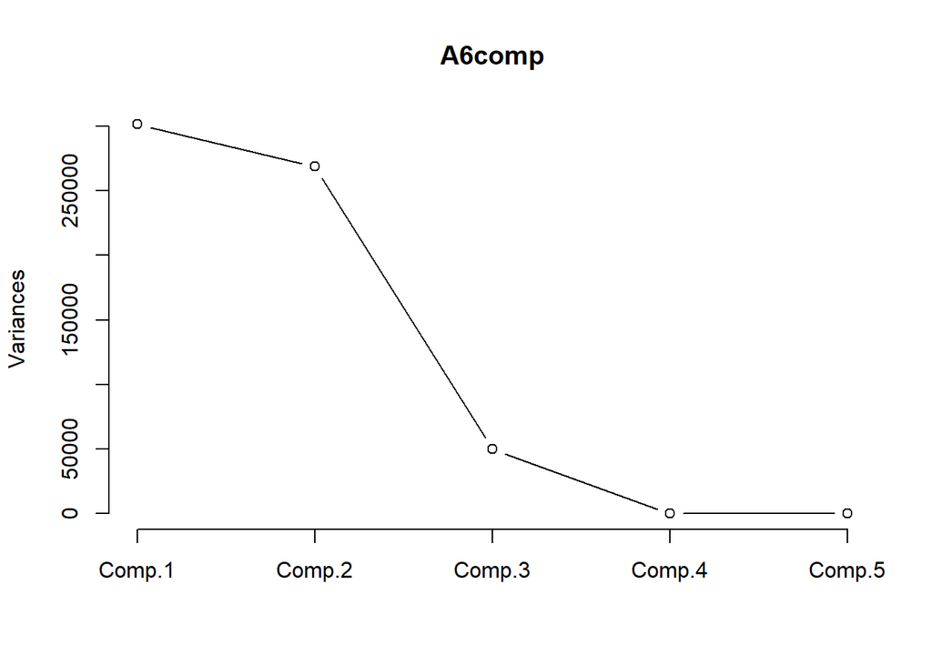

```r
plot(A6comp, type='l')
```

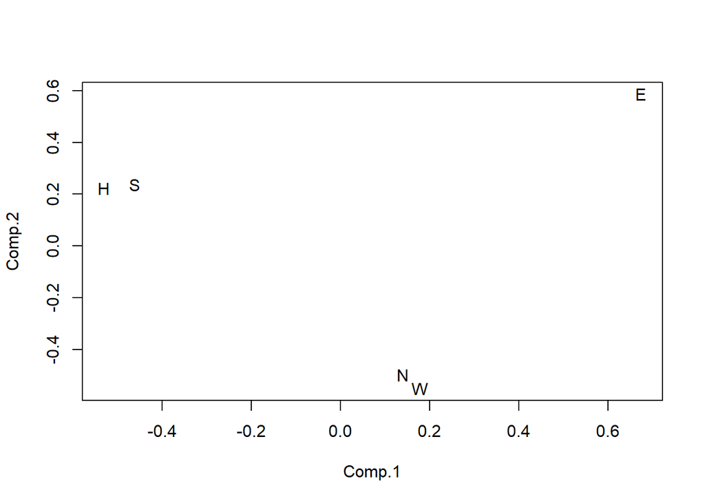

```r
# plot the final 2-dim configuration
A8 <-A6comp$loadings[,1:2]
plot(A8 ,pch="")
points<-c("E","H","N","S","W")  # prepare to label points
text(A8,points)
```